# Effect of delays and capacity on COVID-19 deaths

First, we begin with a simple toy model. Infected individuals can either have a mild or subclinical symptom ($I_m$) or severe symptoms ($I_s$). Severe cases can lead to death $R$ unless they are treated $T$. For now, we assume that individuals with mild or subclinical symptoms will not seek treatment.
$$\begin{aligned}
\frac{dS}{dt} &= - \beta S(I_m + I_s)\\
\frac{dI_m}{dt} &= (1-p) \beta S(I_m + I_s) - \gamma I_m \\
\frac{dI_s}{dt} &= p \beta S(I_m + I_s) - (\gamma + \delta(t)) I_s\\
\frac{dT}{dt} &= \delta(t) I_s - \sigma T \\
\frac{dR}{dt} &= \gamma I_m + \sigma T \\
\frac{dD}{dt} &= \gamma I_s \\
\end{aligned}$$

We compare two models. First, the baseline model assumes that individuals get tested at a constant rate $\delta(t) = \delta_0$. Second, we assume that there is treatment capacity $T_{\textrm{max}}$ (e.g., number of ICU beds). In this case, we assume:
$$\delta(t) = \begin{cases}
\sigma T/I_s & \delta_0 I_s \geq \sigma T_{\textrm{max}}, T \geq T_{\textrm{max}}\\
\delta_0 & \textrm{otherwise}
\end{cases}$$
Therefore, the number of people in treatment stays constant when the resource is at its capacity.

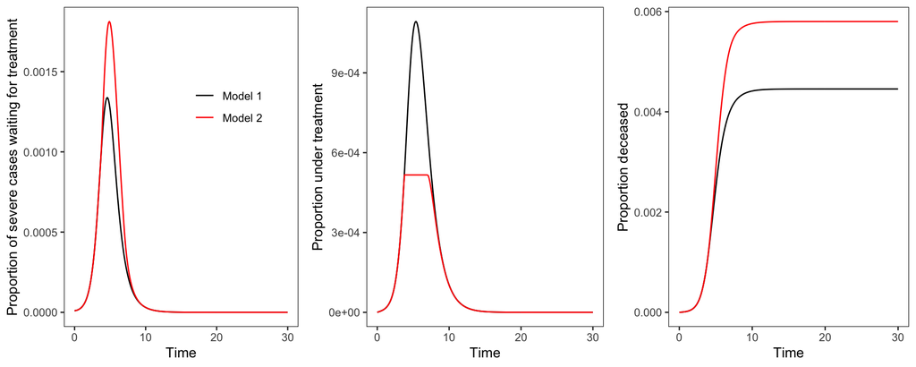

```r
library(deSolve)
library(dplyr)
library(ggplot2); theme_set(theme_bw())
library(gridExtra)

sir1 <- function(t, y, par) {
  with(as.list(c(par, y)), {
    dS <- -beta * S * (I_m+I_s)
    dI_m <- (1-p) * beta * S * (I_m+I_s) - gamma * I_m
    dI_s <- p * beta * S * (I_m+I_s) - (gamma + delta0) * I_s
    dTr <- delta0 * I_s - sigma * Tr ## T stands for TRUE...
    dR <- sigma * I_m + sigma * Tr
    dD <- sigma * I_s

    list(c(dS, dI_m, dI_s, dTr, dR, dD))
  })
}

sir2 <- function(t, y, par) {
  with(as.list(c(par, y)), {
    if (delta0 * I_s >= sigma * Tmax && Tr >= Tmax) {
      delta <- sigma * Tr/I_s
    } else {
      delta <- delta0
    }

    dS <- -beta * S * (I_m+I_s)
    dI_m <- (1-p) * beta * S * (I_m+I_s) - gamma * I_m
    dI_s <- p * beta * S * (I_m+I_s) - (gamma + delta) * I_s
    dTr <- delta * I_s - sigma * Tr ## T stands for TRUE...
    dR <- gamma * I_m + sigma * Tr
    dD <- sigma * I_s

    list(c(dS, dI_m, dI_s, dTr, dR, dD))
  })
}

par <- c(
  beta=2.5,
  gamma=1,
  delta0=1,
  sigma=1,
  p=0.01,
  Tmax=0.0005
)

yini <- c(S=1-1e-3, I_m=1e-3*0.99, I_s=1e-3*0.01, Tr=0, R=0, D=0)
tvec <- seq(0, 30, by=0.1)

sim1 <- as.data.frame(ode(yini, tvec, sir1, par)) %>%
  mutate(
    type="Model 1"
  )

sim2 <- as.data.frame(ode(yini, tvec, sir2, par)) %>%
  mutate(
    type="Model 2"
  )

simall <- bind_rows(sim1, sim2)

g1 <- ggplot(simall) +
  geom_line(aes(time, I_s, col=type)) +
  scale_x_continuous("Time") +
  scale_y_continuous("Proportion of severe cases waiting for treatment") +
  scale_color_manual(values=c(1, 2)) +
  theme(
    panel.grid = element_blank(),
    legend.position = c(0.7, 0.7),
    legend.title = element_blank()
  )

g2 <- ggplot(simall) +
  geom_line(aes(time, Tr, col=type)) +
  scale_x_continuous("Time") +
  scale_y_continuous("Proportion under treatment") +
  scale_color_manual(values=c(1, 2)) +
  theme(
    panel.grid = element_blank(),
    legend.position = "none"
  )

g3 <- ggplot(simall) +
  geom_line(aes(time, D, col=type)) +
  scale_x_continuous("Time") +
  scale_y_continuous("Proportion deceased") +
  scale_color_manual(values=c(1, 2)) +
  theme(
    panel.grid = element_blank(),
    legend.position = "none"
  )

grid.arrange(g1, g2, g3, nrow=1)
```

Then, we can quantify the effect of interaction between resouce capacity and time from infection to treatment on total deaths as well as proportion of deaths due to limited resource.

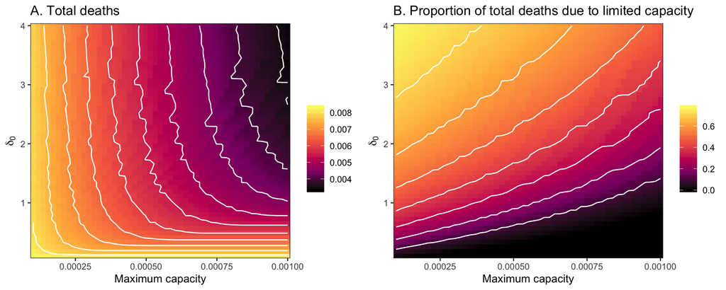

```r
nsim <- 51
Tmaxvec <- seq(0.0001, 0.001, length.out = nsim)
delta0vec <- seq(0.1, 4, length.out=nsim)

simpar <- data.frame(
  Tmax=rep(Tmaxvec, nsim),
  delta0=rep(delta0vec, each=nsim)
)

reslist <- apply(simpar, 1, function(x) {
  newpar <- par

  newpar[["Tmax"]] <- x[1]
  newpar[["delta0"]] <- x[2]

  sim1 <- as.data.frame(ode(yini, tvec, sir1, newpar))

  sim2 <- as.data.frame(ode(yini, tvec, sir2, newpar))

  data.frame(
    Tmax=x[1],
    delta0=x[2],
    total=tail(sim2$D, 1),
    rel=1-tail(sim1$D, 1)/tail(sim2$D, 1)
  )
})

resdata <- reslist %>%
  bind_rows

g4 <- ggplot(resdata) +
  geom_tile(aes(Tmax, delta0, fill=total)) +
  geom_contour(aes(Tmax, delta0, z=total), col="white") +
  scale_x_continuous("Maximum capacity", expand=c(0, 0)) +
  scale_y_continuous(expression(delta[0]), expand=c(0, 0)) +
  scale_fill_gradientn("", colors=c("black", "#8a0072", "#cf2661", "#f66d4e", "#ffb34a", "#f9f871")) +
  ggtitle("A. Total deaths")

g5 <- ggplot(resdata) +
  geom_tile(aes(Tmax, delta0, fill=rel)) +
  geom_contour(aes(Tmax, delta0, z=rel), col="white") +
  scale_x_continuous("Maximum capacity", expand=c(0, 0)) +
  scale_y_continuous(expression(delta[0]), expand=c(0, 0)) +
  scale_fill_gradientn("", colors=c("black", "#8a0072", "#cf2661", "#f66d4e", "#ffb34a", "#f9f871")) +
  ggtitle("B. Proportion of total deaths due to limited capacity")

grid.arrange(g4, g5, nrow=1)
```

It’s always better to get treated as soon as possible to reduce the total number of deaths. However, since there’s resource capacity, the proportion of people that die from the limited capacity increases as people seek treatment quicker…